# EDA Executive Summary - WHO World Health Statistics 2021

Data Science I (STAT 301-1)

Chloe Sokol

## Overview

The data set is sourced from the World Health Organization and represents WHO’s annual World Health Statistics report for the 194 WHO member states in 2021, though most of the data falls under a previous year. The dataset was found on the WHO website within the Global Health Observatory. For 2021, they have a full report as well as a visual summary in addition to the raw .xls file. (https://www.who.int/data/gho/publications/world-health-statistics)

## Executive Summary

The most interesting finding of the long-form EDA was an exploration of the data on vaccine coverage in the WHS dataset. Three immunizations covered by the dataset for young children include Diphtheria-tetanus-pertussis (DTP3) and Pneumococcal conjugate 3rd dose (PCV3) among 1-year-olds, as well as the Measles-containing-vaccine second-dose (MCV2) among the nationally recommended age which is still during young childhood. While the data on each country, region, and global statistics for each vaccine was compiled in the 2021 World Health Statistics Report, observations for these three variables were recorded in 2019.  
The region with the highest DTP3 immunization coverage among 1-year-olds is the European region (95%), followed by the Western Pacific region (94%), the Southeast Asia region (91%), the region of the Americas (84%), the Eastern Mediterranean region (82%), and finally, the African region (74%). For the MCV2 immunization coverage by the nationally recommended age, the European region (92%) had the highest proportion, followed by the Western Pacific region (91%), the Southeast Asia region (83%), the Eastern Mediterranean region and the region of the Americas (75%), and finally, the African region (33%). Finally, the region with the highest PCV3 immunization coverage among 1-year olds is the region of the Americas (83%), followed by the European region (80%), the African region (70%), the Eastern Mediterranean region (52%), the Southeast Asia region (23%), and finally, the Western Pacific region (14%). This data is shown in the faceted bar chart below.

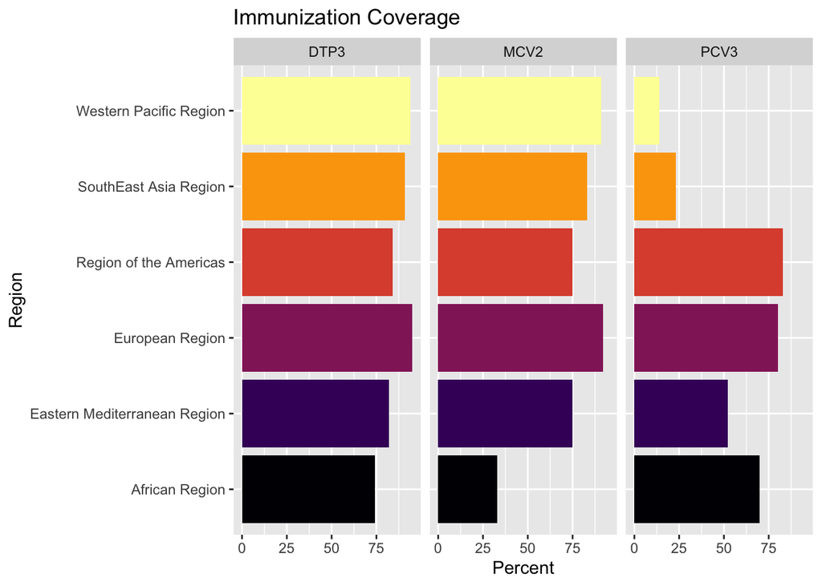

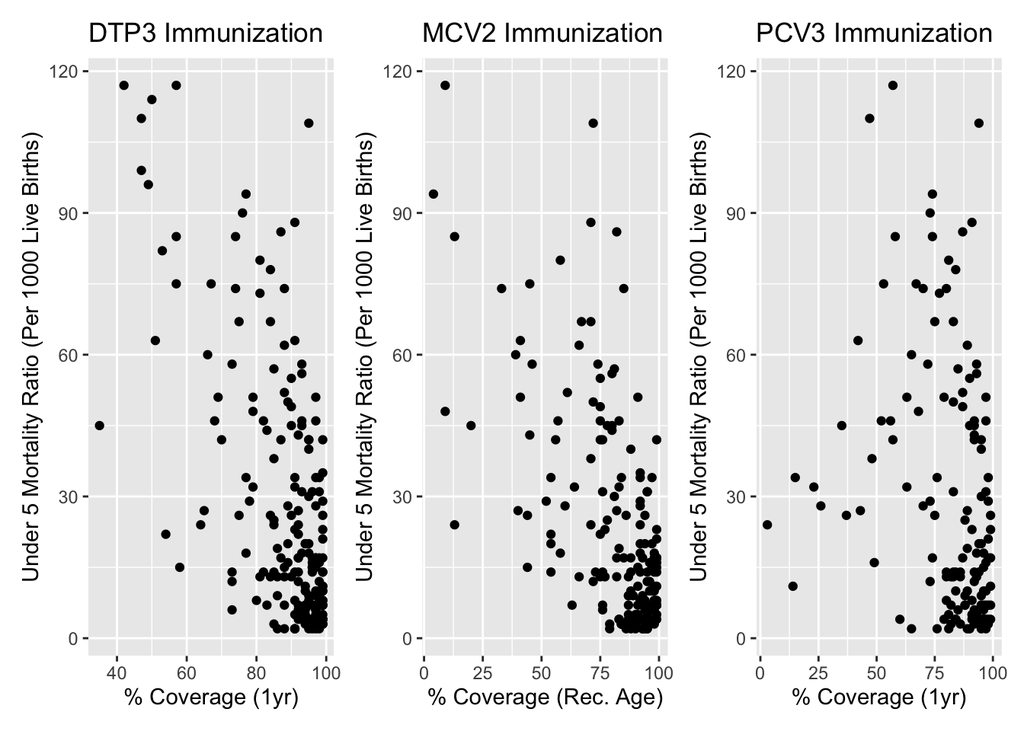